# Analise Custo De Emendas Parlamentares 2024

Gilmar Pires

2024-12-25

## Projeto de Análise de Dados

O objetivo deste projeto é analisar os custos de emendas parlamentares de 2024 que foram liberadas através do **MINISTÉRIO DOS DIREITOS HUMANOS E DA CIDADANIA**. **Esse projeto foi todo elaborado em R, com a utilização de pacotes como** readr**,** dplyr**,** ggplot2**,** tidyr **e** readxl**.**

```r
# Caminho para o arquivo baixado
file_path <- "Planilha_Emendas_ao_OGU_2024 - V1. Dados Abertos.xlsx"

# Ler a planilha do Excel, pulando a primeira linha
df <- read_excel(file_path, skip = 1)



# Filtrar as categorias indesejadas
df <- df %>%
  filter(!UF %in% c(NA, "Não se Aplica", "PDT"))

# Converter a coluna Valor para numérica e ajustar para milhões de R$
df_milhoes <- df %>%
  mutate(Valor = as.numeric(Valor) / 1e6)
```

## Analise de valores totais por UF

Aqui temos um gráfico de barras com o valor total das emendas por UF, onde o destaque é para o estado de **São Paulo** que recebeu o maior valor total em milhões de R$.

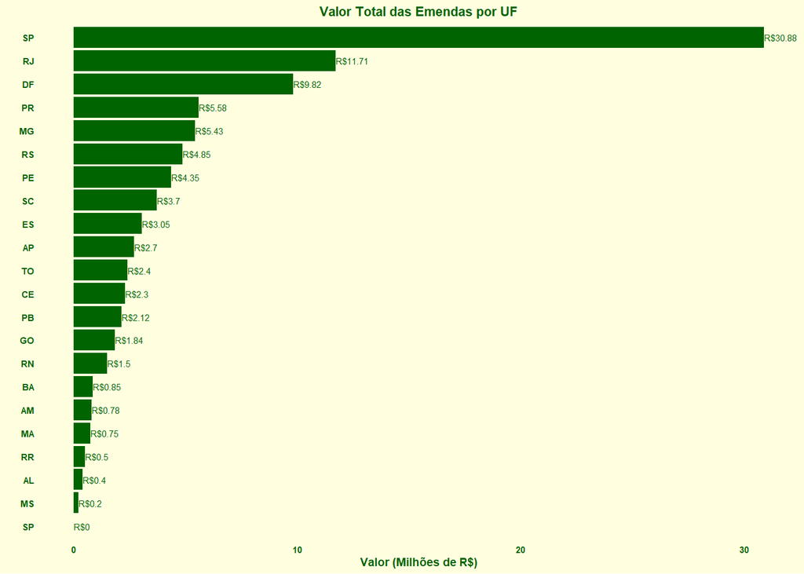

```r
# Criar o gráfico de barras com estilo personalizado e rótulos de valores
df_milhoes %>%
  group_by(UF) %>%
  summarise(total_emendas = sum(Valor, na.rm = TRUE)) %>%
  ggplot(aes(x = reorder(UF, total_emendas), y = total_emendas)) +
  geom_col(fill = "darkgreen") + # Cor das barras em verde escuro
  geom_text(aes(label = paste0("R$", round(total_emendas, 2))), hjust = 0, size = 2, color = "darkgreen") + # Rótulos em branco
  coord_flip() +
  labs(x = "", y = "Valor (Milhões de R$)", title = "Valor Total das Emendas por UF") +
  theme_minimal(base_size = 7) + # Aumentar o tamanho da fonte
  theme(
    panel.grid.major = element_blank(), # Remover linhas de grade maiores
    panel.grid.minor = element_blank(), # Remover linhas de grade menores
    panel.background = element_rect(fill = "lightyellow", color = NA), # Fundo amarelo fraco
    plot.background = element_rect(fill = "lightyellow", color = NA), # Fundo amarelo fraco
    text = element_text(color = "darkgreen", face = "bold"), # Rótulos em verde escuro negrito
    axis.text = element_text(color = "darkgreen", face = "bold"), # Rótulos dos eixos em verde escuro negrito
    axis.title = element_text(color = "darkgreen", face = "bold"), # Título dos eixos em verde escuro negrito
    plot.title = element_text(color = "darkgreen", face = "bold", hjust = 0.5) # Título do gráfico em verde escuro negrito
  )
```

## Análise por partido político

A análise exploratória de dados foi realizada com sucesso, incluindo a leitura e limpeza dos dados, bem como a criação do gráfico de barras mostrando o valor total das emendas por partido político.

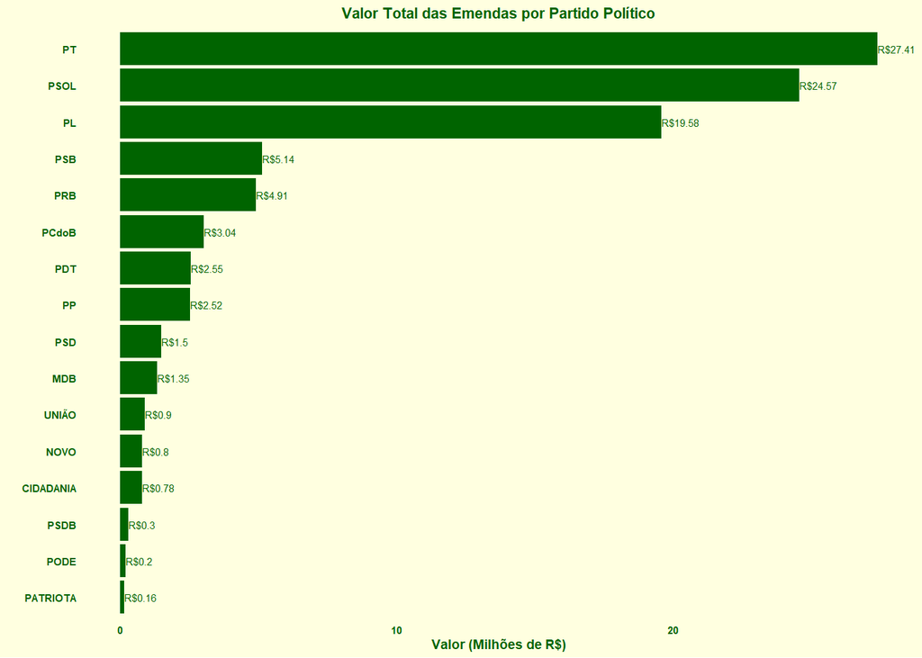

```r
df_milhoes %>%
  group_by(Partido) %>%
  summarise(total_emendas = sum(Valor, na.rm = TRUE)) %>%
  ggplot(aes(x = reorder(Partido, total_emendas), y = total_emendas)) +
  geom_col(fill = "darkgreen") + # Cor das barras em verde escuro
  geom_text(aes(label = paste0("R$", round(total_emendas, 2))), hjust = 0, size = 2, color = "darkgreen") + # Rótulos em branco
  coord_flip() +
  labs(x = "", y = "Valor (Milhões de R$)", title = "Valor Total das Emendas por Partido Político") +
  theme_minimal(base_size = 7) + # Aumentar o tamanho da fonte
  theme(
    panel.grid.major = element_blank(), # Remover linhas de grade maiores
    panel.grid.minor = element_blank(), # Remover linhas de grade menores
    panel.background = element_rect(fill = "lightyellow", color = NA), # Fundo amarelo fraco
    plot.background = element_rect(fill = "lightyellow", color = NA), # Fundo amarelo fraco
    text = element_text(color = "darkgreen", face = "bold"), # Rótulos em verde escuro negrito
    axis.text = element_text(color = "darkgreen", face = "bold"), # Rótulos dos eixos em verde escuro negrito
    axis.title = element_text(color = "darkgreen", face = "bold"), # Título dos eixos em verde escuro negrito
    plot.title = element_text(color = "darkgreen", face = "bold", hjust = 0.5) # Título do gráfico em verde escuro negrito
  )
```

## Ranking por Parlamentar

Aqui fiz um filtro com os 30 parlamentares com maior faturamento em emendas parlamentares.

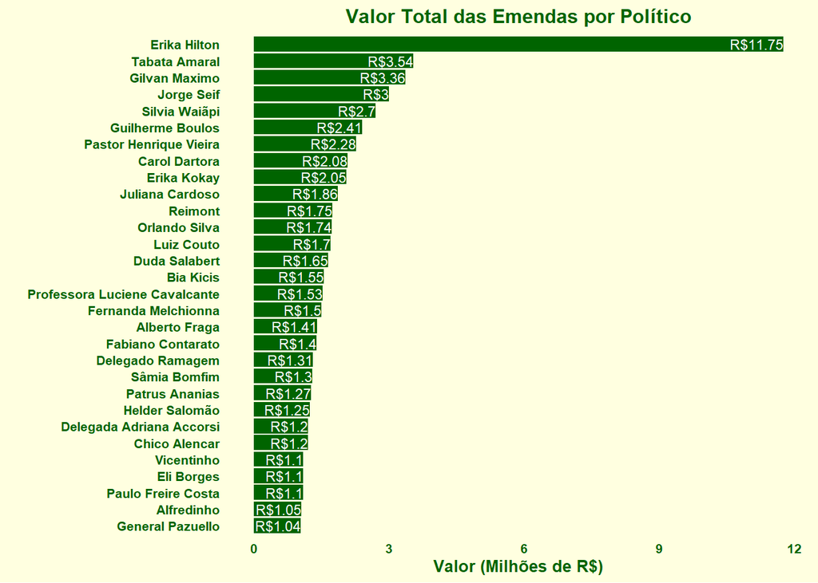

```r
# Criar o gráfico de barras com estilo personalizado e rótulos de valores
df_milhoes %>%
  group_by(Autor) %>%
  summarise(total_emendas = sum(Valor, na.rm = TRUE)) %>%
  top_n(30, total_emendas) %>%
  ggplot(aes(x = reorder(Autor, total_emendas), y = total_emendas)) +
  geom_col(fill = "darkgreen") + # Cor das barras em verde escuro
  geom_text(aes(label = paste0("R$", round(total_emendas, 2))), hjust = 1, size = 3, color = "white") + # Rótulos em verde
  coord_flip() +
  labs(x = "", y = "Valor (Milhões de R$)", title = "Valor Total das Emendas por Político") +
  theme_minimal(base_size = 10) + # Aumentar o tamanho da fonte
  theme(
    panel.grid.major = element_blank(), # Remover linhas de grade maiores
    panel.grid.minor = element_blank(), # Remover linhas de grade menores
    panel.background = element_rect(fill = "lightyellow", color = NA), # Fundo amarelo fraco
    plot.background = element_rect(fill = "lightyellow", color = NA), # Fundo amarelo fraco
    text = element_text(color = "darkgreen", face = "bold"), # Rótulos em verde escuro negrito
    axis.text = element_text(color = "darkgreen", face = "bold"), # Rótulos dos eixos em verde escuro negrito
    axis.title = element_text(color = "darkgreen", face = "bold"), # Título dos eixos em verde escuro negrito
    plot.title = element_text(color = "darkgreen", face = "bold", hjust = 0.5) # Título do gráfico em verde escuro negrito
  )
```

## Quantidade de Emendas Parlamentares por Parlamentar

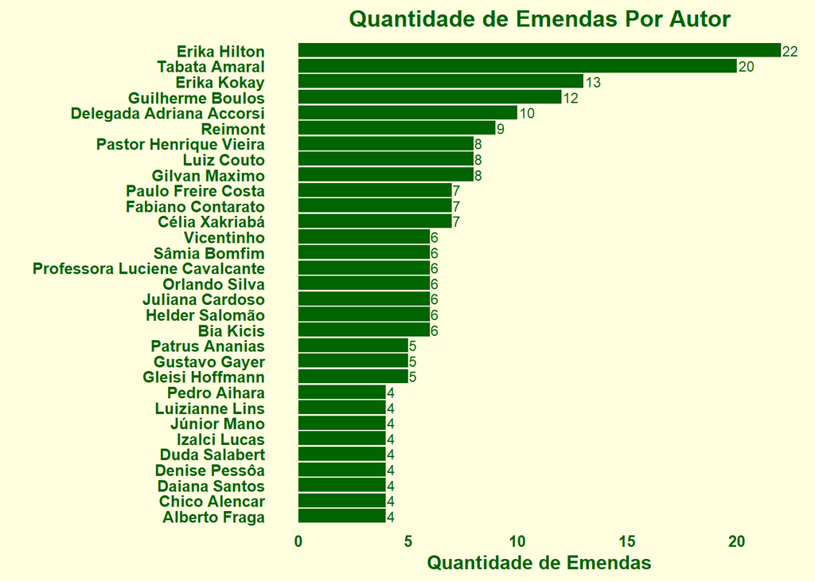

```r
# Agrupar os dados e contar a quantidade de emendas por Autor
df_quantidade <- df %>%
  group_by(Autor) %>%
  summarise(quantidade_emendas = n()) %>%
  filter(quantidade_emendas != 0) %>% # Filtrar valores zero
  top_n(30, quantidade_emendas) # Selecionar os 30 autores com maior quantidade de emendas

# Criar o gráfico de barras com estilo personalizado
ggplot(df_quantidade, aes(x = reorder(Autor, quantidade_emendas), y = quantidade_emendas)) +
  geom_col(fill = "darkgreen") + # Cor das barras em verde escuro
  geom_text(aes(label = quantidade_emendas), hjust = -0.1, size = 3, color = "darkgreen") + # Rótulos em verde
  coord_flip() +
  labs(x = "", y = "Quantidade de Emendas", title = "Quantidade de Emendas Por Autor") +
  theme_minimal(base_size = 12) + # Aumentar o tamanho da fonte
  theme(
    panel.grid.major = element_blank(), # Remover linhas de grade maiores
    panel.grid.minor = element_blank(), # Remover linhas de grade menores
    panel.background = element_rect(fill = "lightyellow", color = NA), # Fundo amarelo fraco
    plot.background = element_rect(fill = "lightyellow", color = NA), # Fundo amarelo fraco
    text = element_text(color = 'darkgreen', face = 'bold'), # Rótulos em verde escuro negrito
    axis.text = element_text(color = 'darkgreen', face = 'bold'), # Rótulos dos eixos em verde escuro negrito
    axis.title = element_text(color = 'darkgreen', face = 'bold'), # Título dos eixos em verde escuro negrito
    plot.title = element_text(color = 'darkgreen', face = 'bold', hjust = 0.5) # Título do gráfico em verde escuro negrito
  )
```

## Valor Total por área beneficiada com os recursos das Emendas Parlamentares

Aqui temos as áreas beneficiadas com os recursos das emendas parlamentares, com destaque para a área de **Sec. Nac. dos Direitos das Pessoas LGBTQIA+** que recebeu o maior valor total em milhões de R$.

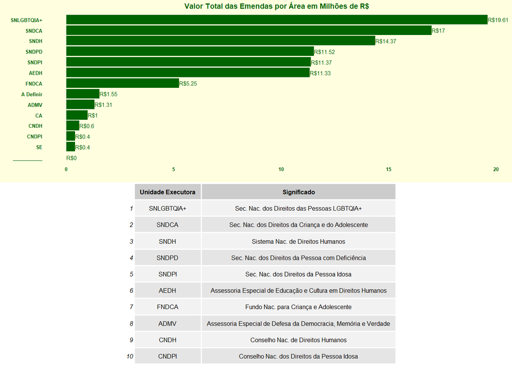

```r
# Criar uma tabela de significados das siglas
siglas <- tibble(
  `Unidade Executora` = c("SNLGBTQIA+", "SNDCA", "SNDH", "SNDPD", "SNDPI", "AEDH", "FNDCA", "ADMV", "CNDH", "CNDPI"),
  Significado = c(
    "Sec. Nac. dos Direitos das Pessoas LGBTQIA+", "Sec. Nac. dos Direitos da Criança e do Adolescente",
    "Sistema Nac. de Direitos Humanos", "Sec. Nac. dos Direitos da Pessoa com Deficiência", "Sec. Nac. dos Direitos da Pessoa Idosa",
    "Assessoria Especial de Educação e Cultura em Direitos Humanos", "Fundo Nac. para Criança e Adolescente",
    "Assessoria Especial de Defesa da Democracia, Memória e Verdade", "Conselho Nac. de Direitos Humanos",
    "Conselho Nac. dos Direitos da Pessoa Idosa"
  )
)

# Gráfico de barras
p <- df_milhoes %>%
  group_by(`Unidade Executora`) %>%
  summarise(total_emendas = sum(Valor, na.rm = TRUE)) %>%
  ggplot(aes(x = reorder(`Unidade Executora`, total_emendas), y = total_emendas)) +
  geom_col(fill = "darkgreen") + # Cor das barras em verde escuro
  geom_text(aes(label = paste0("R$", round(total_emendas, 2))), hjust = 0, size = 2, color = "darkgreen") + # Rótulos em verde
  coord_flip() +
  labs(x = "", y = "", title = "Valor Total das Emendas por Área em Milhões de R$") +
  theme_minimal(base_size = 6) + # Aumentar o tamanho da fonte
  theme(
    panel.grid.major = element_blank(), # Remover linhas de grade maiores
    panel.grid.minor = element_blank(), # Remover linhas de grade menores
    panel.background = element_rect(fill = "lightyellow", color = NA), # Fundo amarelo fraco
    plot.background = element_rect(fill = "lightyellow", color = NA), # Fundo amarelo fraco
    text = element_text(color = "darkgreen", face = "bold"), # Rótulos em verde escuro negrito
    axis.text = element_text(color = "darkgreen", face = "bold"), # Rótulos dos eixos em verde escuro negrito
    axis.title = element_text(color = "darkgreen", face = "bold"), # Título dos eixos em verde escuro negrito
    plot.title = element_text(color = "darkgreen", face = "bold", hjust = 0.5) # Título do gráfico em verde escuro negrito
  )

# Tabela com significados das siglas com fonte menor
table_grob <- tableGrob(siglas, theme = ttheme_default(base_size = 6))

# Plotar gráfico e tabela juntos, ajustando a altura da tabela de siglas
grid.arrange(p, table_grob, ncol = 1, heights = c(0.5, 0.5))
```

## Distribuição dos recursos por instituição

A grande maioria dos recursos são destinados a Instituições Privadas sem Fins Lucrativos.

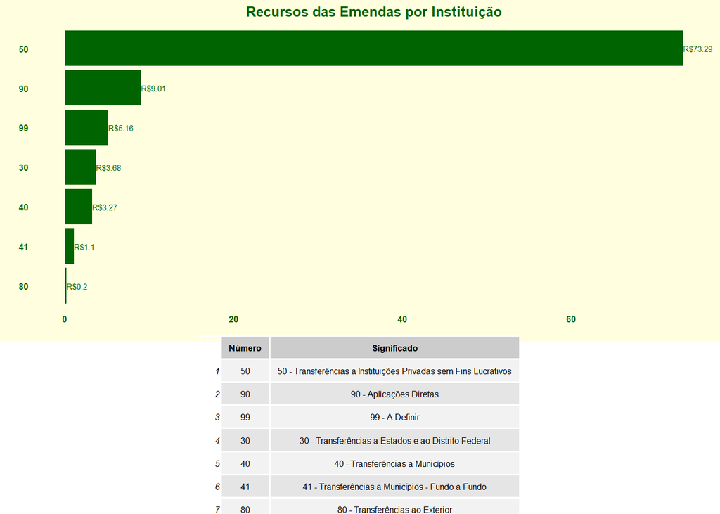

```r
# Agrupar os dados e somar os valores das emendas por Modalidade
df_instituicoes <- df_milhoes %>%
  group_by(`Modalidade`) %>%
  summarise(total_emendas = sum(Valor, na.rm = TRUE))

# Extrair os números das variáveis de Modalidade
df_instituicoes <- df_instituicoes %>%
  mutate(numero = sub(" - .*", "", Modalidade))

# Criar o gráfico de barras com rótulos simplificados (números)
p <- ggplot(df_instituicoes, aes(x = reorder(numero, total_emendas), y = total_emendas)) +
  geom_col(fill = "darkgreen") + # Cor das barras em verde escuro
  geom_text(aes(label = paste0("R$", round(total_emendas, 2))),
            hjust = 0, size = 2, color = "darkgreen") + # Rótulos fora das barras
  coord_flip() +
  labs(x = "", y = "", title = "Recursos das Emendas por Instituição") +
  theme_minimal(base_size = 8) + # Aumentar o tamanho da fonte
  theme(
    panel.grid.major = element_blank(), # Remover linhas de grade maiores
    panel.grid.minor = element_blank(), # Remover linhas de grade menores
    panel.background = element_rect(fill = "lightyellow", color = NA), # Fundo amarelo fraco
    plot.background = element_rect(fill = "lightyellow", color = NA), # Fundo amarelo fraco
    text = element_text(color = 'darkgreen', face = 'bold'), # Rótulos em verde escuro negrito
    axis.text = element_text(color = 'darkgreen', face = 'bold'), # Rótulos dos eixos em verde escuro negrito
    axis.title = element_text(color = 'darkgreen', face = 'bold'), # Título dos eixos em verde escuro negrito
    plot.title = element_text(color = 'darkgreen', face = 'bold', hjust = 0.5) # Título do gráfico em verde escuro negrito
  )

# Criar a tabela de legenda com significados das siglas
siglas_1 <- tibble(
  Número = c(50, 90, 99, 30, 40, 41, 80),
  Significado = c(
    "50 - Transferências a Instituições Privadas sem Fins Lucrativos",
    "90 - Aplicações Diretas",
    "99 - A Definir",
    "30 - Transferências a Estados e ao Distrito Federal",
    "40 - Transferências a Municípios",
    "41 - Transferências a Municípios - Fundo a Fundo",
    "80 - Transferências ao Exterior"))

# Tabela de legenda
table_grob <- tableGrob(siglas_1, theme = ttheme_default(base_size = 6))

# Plotar gráfico e tabela juntos
grid.arrange(p, table_grob, ncol = 1, heights = c(2, 1))
```

## Conclusão

### Fonte dos Dados

Esses dados foram coletados do site de Dados Abertos do Governo Federal, *https://dados.gov.br/dados/conjuntos-dados/emendas-parlamentares-mdhc*.